# MolEco March 19, 2015

19/3/2015

## Outline

- Hill / General / True Diversity
- Richness
- Evenness
- Shannon Diversity
- Rényi entropy
- (Inverse) Simpson
- Berger–Parker
- Alpha, Beta and Gamma Diversity

## Hill Index / True Diversity / General Diversity

- \(M_{q−1}\): weighted average relative abundance
- \(R\): richness (total number of species)
- \(p_i\): Relative abundance of the \(i^{th}\) species
- \(q\): order of diversity. Sensitivity to rare species.

## \(M_{q−1}\): weighted average relative abundance

## Hill Index or True / General Diversity

\({}^q{D} = \frac{1}{M_{q-1}} = \frac{1}{\sqrt[q-1]{\sum_{i=1}^R p_i p_i^{q-1}}} = (\sum_{i=1}^R p_i^{q})^{1/(1-q)}\)

With small \(q\), weight is given to rare species:

- q = 0: Total Species Richness
- q = 1: Shannon Diversity
- q = 2: Inverse Simpson Diversity
- \(q \rightarrow \infty\): Inverse Berger–Parker

Increasing \(q\) increases the weight of the most abundant species, decreasing diversity.

## Richness (q=0): Total number of species

\({}^0{D} = (\sum_{i=1}^R p_i^{0})^{1/(1-0)} = \sum_{i=1}^R 1 = R\)

Equal weight given to each species, regardless of abundance

## Richness vs. Evenness ?

Diversity = Richness * Evenness

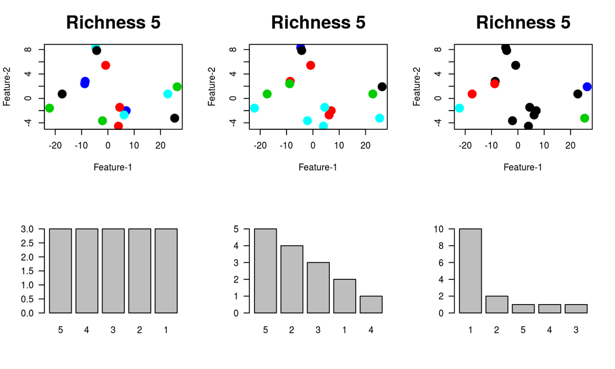

## Shannon Diversity (q=1)

Shannon–Wiener / Shannon–Weaver / Shannon-Weaner / Shannon entropy. The general diversity is undefined but the limit \(q \rightarrow 1\) is well defined:

\({}^1{D} = exp(-\sum_{i=1}^R p_i ln (p_i))\)

Exponential of the Shannon entropy. Effective species number. Quantifies uncertainty: difficulty of predicting next observed species:

## Shannon Diversity (q=1)

Quantifies uncertainty: difficulty of correctly predicting the next observed species.

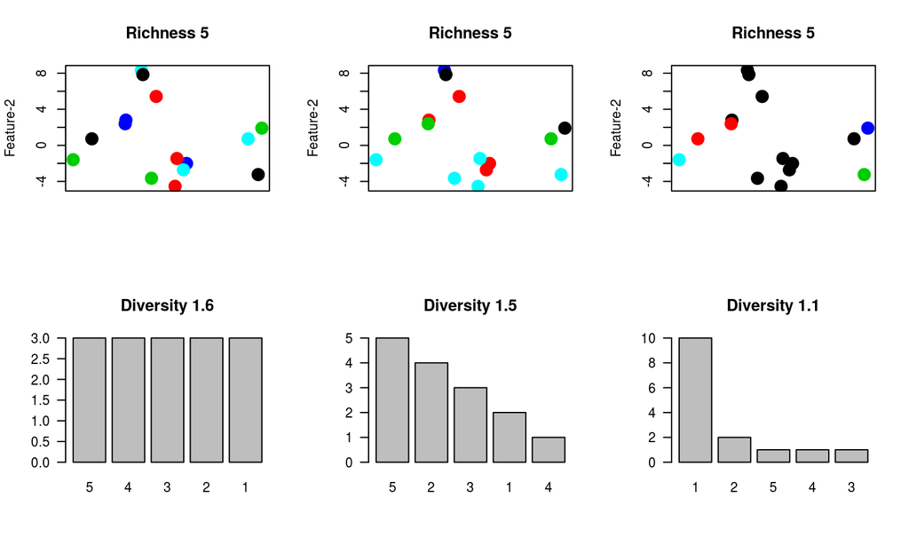

## Diversity Formation

## Rényi entropy

Generalization of the Shannon entropy to other values of q than unity.

\({}^q{H} = ln({}^q{D})\)

## Simpson Index

(Herfindahl / Herfindahl–Hirschman / HH / Hunter–Gaston Index). **Probability that randomly sampled individuals represent the same species:** \(\lambda \sim \sum_{i=1}^R p_i^2\). This increases with species dominance. Therefore inverse indices are used for diversity.

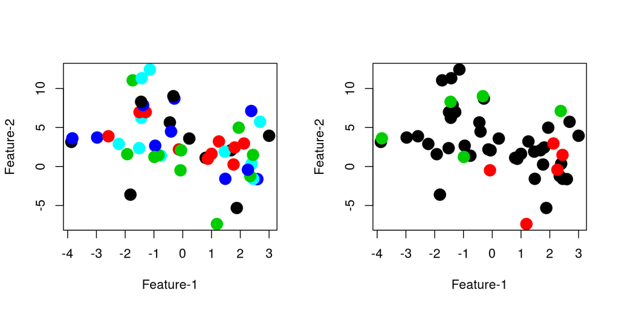

## Inverse Simpson Diversity

**Gini-Simpson** / probability of interspecific encounter (PIE) / Gibbs–Martin / Blau Index: probability that the two entities represent **different** types: \(1 - \lambda\)

**Inverse Simpson** \({}^2{D} = \frac{1}{\sqrt[2-1]{\sum_{i=1}^R p_i p_i^{2-1}}} = \frac{1}{\sum_{i=1}^R p_i^2} = \frac{1}{\lambda}\)

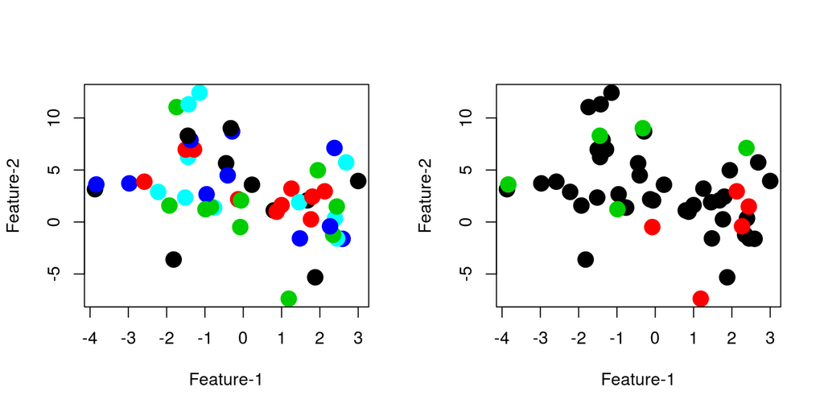

## Berger–Parker Index

Maximum relative abundance: \(max(p_i) = \frac{1}{{}^{\infty}{D}}\)

## Summary: General (\(\alpha\)) Diversity

\({}^q{D} = \frac{1}{M_{q-1}} = (\sum_{i=1}^R p_i^{q})^{1/(1-q)}\)

With small \(q\), weight is given to rare species:

- q = 0: Species Richness (total count)
- q = 1: Shannon Diversity (information content)
- q = 2: Inverse Simpson (sampling probability)
- \(q \rightarrow \infty\): Inverse Berger–Parker (most abundant species)

Increasing \(q\) increases the weight of the most abundant species and decreases diversity.

## Alpha, Beta, Gamma Diversity

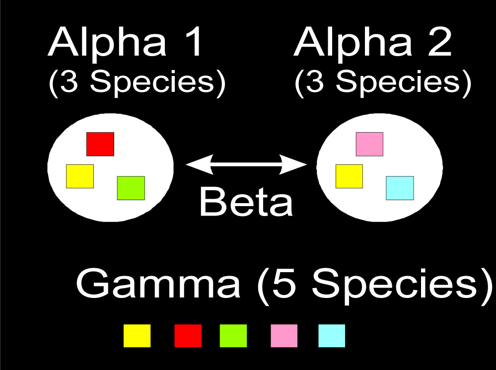

## Source code for these slides:

https://github.com/microbiome/slides/

[figure not shown]